# cyclist_analysis

Judy

2025-04-29

### 1. About the Project

Cyclistic is an imaginary bike-share company based on real-world data from Divvy in Chicago. This project analyzes the behavioral differences between casual riders and annual members to propose marketing strategies to increase annual memberships.

Goal:

Understand how casual and annual riders use bikes differently.

Provide actionable insights to the marketing team.

Key Stakeholders:

Cyclistic Executive Team

Lily Moreno, Director of Marketing

### 2. Data Overview

Period: September 2023 to August 2024

Source: Divvy Bike Share Data

```r
library(tidyverse)
library(lubridate)
```

### 3. Load Monthly Ride Data

Importing 12 separate monthly trip data files, from September 2023 to August 2024.

```r
data_202309 <- read_csv ("C:/Users/judin/OneDrive/Documents/data_analysis/google_certificate/capstone_cyclistic/202309-divvy-tripdata/202309-divvy-tripdata.csv")
data_202310 <- read_csv ("C:/Users/judin/OneDrive/Documents/data_analysis/google_certificate/capstone_cyclistic/202310-divvy-tripdata/202310-divvy-tripdata.csv")
data_202311 <- read_csv ("C:/Users/judin/OneDrive/Documents/data_analysis/google_certificate/capstone_cyclistic/202311-divvy-tripdata/202311-divvy-tripdata.csv")
data_202312 <- read_csv ("C:/Users/judin/OneDrive/Documents/data_analysis/google_certificate/capstone_cyclistic/202312-divvy-tripdata/202312-divvy-tripdata.csv")
data_202401 <- read_csv ("C:/Users/judin/OneDrive/Documents/data_analysis/google_certificate/capstone_cyclistic/202401-divvy-tripdata/202401-divvy-tripdata.csv")
data_202402 <- read_csv ("C:/Users/judin/OneDrive/Documents/data_analysis/google_certificate/capstone_cyclistic/202402-divvy-tripdata/202402-divvy-tripdata.csv")
data_202403 <- read_csv ("C:/Users/judin/OneDrive/Documents/data_analysis/google_certificate/capstone_cyclistic/202403-divvy-tripdata/202403-divvy-tripdata.csv")
data_202404 <- read_csv ("C:/Users/judin/OneDrive/Documents/data_analysis/google_certificate/capstone_cyclistic/202404-divvy-tripdata/202404-divvy-tripdata.csv")
data_202405 <- read_csv ("C:/Users/judin/OneDrive/Documents/data_analysis/google_certificate/capstone_cyclistic/202405-divvy-tripdata/202405-divvy-tripdata.csv")
data_202406 <- read_csv ("C:/Users/judin/OneDrive/Documents/data_analysis/google_certificate/capstone_cyclistic/202406-divvy-tripdata/202406-divvy-tripdata.csv")
data_202407 <- read_csv ("C:/Users/judin/OneDrive/Documents/data_analysis/google_certificate/capstone_cyclistic/202407-divvy-tripdata/202407-divvy-tripdata.csv")
data_202408 <- read_csv ("C:/Users/judin/OneDrive/Documents/data_analysis/google_certificate/capstone_cyclistic/202408-divvy-tripdata/202408-divvy-tripdata.csv")
```

### 4. Check the First Few Rows of the Data

Quickly inspect the first few rows of the September 2023 trip data to ensure the data has been imported correctly.

```r
head(data_202309, 10)
```

```
## # A tibble: 10 × 13
##    ride_id          rideable_type started_at          ended_at
##    <chr>            <chr>         <dttm>              <dttm>
##  1 011C1903BF4E2E28 classic_bike  2023-09-23 00:27:50 2023-09-23 00:33:27
##  2 87DB80E048A1BF9F classic_bike  2023-09-02 09:26:43 2023-09-02 09:38:19
##  3 7C2EB7AF669066E3 electric_bike 2023-09-25 18:30:11 2023-09-25 18:41:39
##  4 57D197B010269CE3 classic_bike  2023-09-13 15:30:49 2023-09-13 15:39:18
##  5 8A2CEA7C8C8074D8 classic_bike  2023-09-18 15:58:58 2023-09-18 16:05:04
##  6 03F7044D1304CD58 electric_bike 2023-09-15 20:19:25 2023-09-15 20:30:27
##  7 672503E0FC0835EC electric_bike 2023-09-27 16:52:18 2023-09-27 17:03:22
##  8 1D806492F95973AC electric_bike 2023-09-17 11:07:05 2023-09-17 11:13:39
##  9 40D9EF382CC6C53D classic_bike  2023-09-17 11:58:50 2023-09-17 12:08:36
## 10 C60CE661AF7ECC93 electric_bike 2023-09-07 20:52:43 2023-09-07 21:06:51
## # ℹ 9 more variables: start_station_name <chr>, start_station_id <chr>,
## #   end_station_name <chr>, end_station_id <chr>, start_lat <dbl>,
## #   start_lng <dbl>, end_lat <dbl>, end_lng <dbl>, member_casual <chr>
```

### 5. Combining the dataset

(rbind:rigid and risky / bind_rows:forgiving, flexible)

```r
data_combined <- bind_rows(data_202309, data_202310, data_202311, data_202312,
                       data_202401, data_202402, data_202403, data_202404,
                       data_202405, data_202406, data_202407, data_202408)
```

### 6. Normalization

Step to reduce noise, improve performance, and focus the analysis. Excluded columns such as station names and coordinates, as they are either incomplete or not essential to the current behavioral comparison between casual and annual riders.

```r
rider_info <- data_combined %>%
  select(ride_id, rideable_type, started_at, ended_at, member_casual)
```

### 7. Checking the process

Check the first few rows and structure of the cleaned dataset to verify that the normalization step was successful.

```r
head(rider_info)
```

```
## # A tibble: 6 × 5
##   ride_id    rideable_type started_at          ended_at            member_casual
##   <chr>      <chr>         <dttm>              <dttm>              <chr>
## 1 011C1903B… classic_bike  2023-09-23 00:27:50 2023-09-23 00:33:27 member
## 2 87DB80E04… classic_bike  2023-09-02 09:26:43 2023-09-02 09:38:19 member
## 3 7C2EB7AF6… electric_bike 2023-09-25 18:30:11 2023-09-25 18:41:39 member
## 4 57D197B01… classic_bike  2023-09-13 15:30:49 2023-09-13 15:39:18 member
## 5 8A2CEA7C8… classic_bike  2023-09-18 15:58:58 2023-09-18 16:05:04 member
## 6 03F7044D1… electric_bike 2023-09-15 20:19:25 2023-09-15 20:30:27 member
```

```r
glimpse(rider_info)
```

```
## Rows: 5,699,639
## Columns: 5
## $ ride_id       <chr> "011C1903BF4E2E28", "87DB80E048A1BF9F", "7C2EB7AF669066E…
## $ rideable_type <chr> "classic_bike", "classic_bike", "electric_bike", "classi…
## $ started_at    <dttm> 2023-09-23 00:27:50, 2023-09-02 09:26:43, 2023-09-25 18…
## $ ended_at      <dttm> 2023-09-23 00:33:27, 2023-09-02 09:38:19, 2023-09-25 18…
## $ member_casual <chr> "member", "member", "member", "member", "member", "membe…
```

### 8. Data Cleaning

8.1. Verifying missing values.

```r
colSums(is.na(rider_info))
```

```
##       ride_id rideable_type    started_at      ended_at member_casual
##             0             0             0             0             0
```

8.2. Deleting NA rows.(If necessary, not in my case because there are no missing valures.)

```r
rider_info <- rider_info %>%
  filter(!is.na(started_at), !is.na(ended_at))
```

### 9. Calculating ride_length of bikers

I need to calculate before separating the time and the data to avoid later intrusion of adding the dates into the time column.

```r
rider_info <- rider_info %>%
  mutate(
    ride_length = as.numeric(difftime(ended_at, started_at, units = "mins"))
  )
```

```r
head(rider_info, 10)
```

```
## # A tibble: 10 × 6
##    ride_id   rideable_type started_at          ended_at            member_casual
##    <chr>     <chr>         <dttm>              <dttm>              <chr>
##  1 011C1903… classic_bike  2023-09-23 00:27:50 2023-09-23 00:33:27 member
##  2 87DB80E0… classic_bike  2023-09-02 09:26:43 2023-09-02 09:38:19 member
##  3 7C2EB7AF… electric_bike 2023-09-25 18:30:11 2023-09-25 18:41:39 member
##  4 57D197B0… classic_bike  2023-09-13 15:30:49 2023-09-13 15:39:18 member
##  5 8A2CEA7C… classic_bike  2023-09-18 15:58:58 2023-09-18 16:05:04 member
##  6 03F7044D… electric_bike 2023-09-15 20:19:25 2023-09-15 20:30:27 member
##  7 672503E0… electric_bike 2023-09-27 16:52:18 2023-09-27 17:03:22 member
##  8 1D806492… electric_bike 2023-09-17 11:07:05 2023-09-17 11:13:39 member
##  9 40D9EF38… classic_bike  2023-09-17 11:58:50 2023-09-17 12:08:36 member
## 10 C60CE661… electric_bike 2023-09-07 20:52:43 2023-09-07 21:06:51 member
## # ℹ 1 more variable: ride_length <dbl>
```

### 10. Rounding Ride Duration

To enhance readability and simplify analysis, we rounded the `ride_length` values to two decimal places.

```r
rider_info$ride_length <- round(rider_info$ride_length, 2)
```

```r
head(rider_info, 10)
```

```
## # A tibble: 10 × 6
##    ride_id   rideable_type started_at          ended_at            member_casual
##    <chr>     <chr>         <dttm>              <dttm>              <chr>
##  1 011C1903… classic_bike  2023-09-23 00:27:50 2023-09-23 00:33:27 member
##  2 87DB80E0… classic_bike  2023-09-02 09:26:43 2023-09-02 09:38:19 member
##  3 7C2EB7AF… electric_bike 2023-09-25 18:30:11 2023-09-25 18:41:39 member
##  4 57D197B0… classic_bike  2023-09-13 15:30:49 2023-09-13 15:39:18 member
##  5 8A2CEA7C… classic_bike  2023-09-18 15:58:58 2023-09-18 16:05:04 member
##  6 03F7044D… electric_bike 2023-09-15 20:19:25 2023-09-15 20:30:27 member
##  7 672503E0… electric_bike 2023-09-27 16:52:18 2023-09-27 17:03:22 member
##  8 1D806492… electric_bike 2023-09-17 11:07:05 2023-09-17 11:13:39 member
##  9 40D9EF38… classic_bike  2023-09-17 11:58:50 2023-09-17 12:08:36 member
## 10 C60CE661… electric_bike 2023-09-07 20:52:43 2023-09-07 21:06:51 member
## # ℹ 1 more variable: ride_length <dbl>
```

### 11. Cleaning Data -> removing abnormal entries in ride duration

```r
rider_info %>%
  filter(ride_length <= 0 | ride_length >= 1440) %>%
  nrow()
```

```
## [1] 9196
```

```r
sum(rider_info$ride_length <= 0)
```

```
## [1] 1301
```

```r
sum(rider_info$ride_length >= 1440)
```

```
## [1] 7895
```

```r
rider_info <- rider_info %>%
  filter(
    !is.na(ride_length),
    ride_length > 0,
    ride_length < 1440  # over 24 hours (remove abnormal entries)
  )
```

### 12. Summary Table for Rider Type Comparison

Creating a summary table to organize and simplify the original ride data.

This normalization and summarization step is critical to avoid being overwhelmed by raw data and to focus the analysis on patterns that are meaningful for marketing strategy development.

```r
summary_table <- rider_info %>%
  group_by(member_casual) %>%
  summarise(
    total_ride_time = sum(ride_length),
    total_ride_count = n()
  ) %>%
  mutate(
    share_of_total_time = round(total_ride_time / sum(total_ride_time) * 100, 1),
    share_of_total_rides = round(total_ride_count / sum(total_ride_count) * 100, 1)
  )
```

```r
summary_long <- summary_table %>%
  select(member_casual, share_of_total_time, share_of_total_rides) %>%
  pivot_longer(
    cols = c(share_of_total_time, share_of_total_rides),
    names_to = "metric",
    values_to = "percentage"
  ) %>%
  mutate(
    metric = case_when(
      metric == "share_of_total_time" ~ "Total Bike Time",
      metric == "share_of_total_rides" ~ "Total Riders"
    )
  )
```

### 13. Horizontal Bar Chart: Casual vs Member Usage Patterns

To better emphasize the behavioral differences between casual and member riders,  
we visualized the total ride time and ride count using a horizontal grouped bar chart.

This chart makes the contrast clear: - Casual riders take **fewer rides** but spend **almost as much total time** riding as members. - Member riders account for **more than 60% of total rides**, yet the **total ride time is nearly equal**.

This insight is important when considering strategies to convert casual users to annual members.

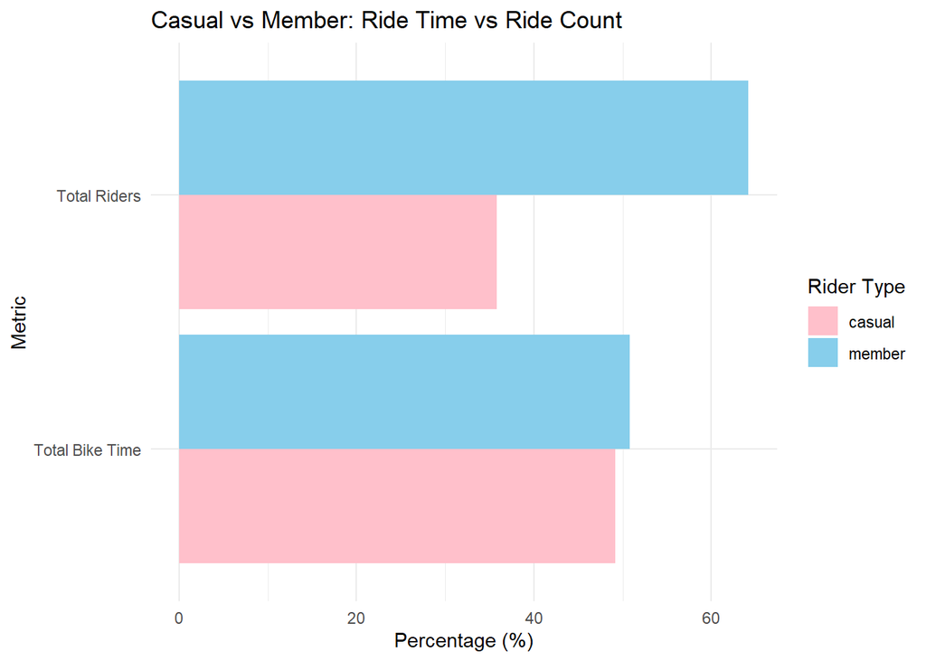

```r
ggplot(summary_long, aes(x = percentage, y = metric, fill = member_casual)) +
  geom_bar(stat = "identity", position = "dodge") +
    scale_y_discrete(
    labels = c("share_of_total_time" = "Total Bike Time",
               "share_of_total_rides" = "Total Riders")
  ) +
  scale_fill_manual(
    values = c("casual" = "pink", "member" = "skyblue")
  ) +
  labs(
    title = "Casual vs Member: Ride Time vs Ride Count",
    x = "Percentage (%)",
    y = "Metric",
    fill = "Rider Type"
  ) +
  theme_minimal()
```

⚠️ Note on Data Limitation:

The dataset does not include user identifiers, so it’s not possible to determine how many unique users are included in each rider type.  
As a result, our analysis focuses on the **total number of rides**, rather than **the number of individual users**.  
This limitation is important to remember when interpreting ride counts for casual vs. member users.

### 14. Separating Date and Time

Instead of splitting the datetime columns using `separate()`,  
I extracted the date and time components using `mutate()` and `format()` functions.  
This approach avoids data type issues and allows us to retain the original datetime columns for further calculations like `ride_length`.

```r
rider_info <- rider_info %>%
  mutate(
    start_date = as.Date(started_at),
    start_time = format(started_at, format = "%H:%M:%S"),
    end_date = as.Date(ended_at),
    end_time = format(ended_at, format = "%H:%M:%S")
  )
```

```r
head(rider_info)
```

```
## # A tibble: 6 × 10
##   ride_id    rideable_type started_at          ended_at            member_casual
##   <chr>      <chr>         <dttm>              <dttm>              <chr>
## 1 011C1903B… classic_bike  2023-09-23 00:27:50 2023-09-23 00:33:27 member
## 2 87DB80E04… classic_bike  2023-09-02 09:26:43 2023-09-02 09:38:19 member
## 3 7C2EB7AF6… electric_bike 2023-09-25 18:30:11 2023-09-25 18:41:39 member
## 4 57D197B01… classic_bike  2023-09-13 15:30:49 2023-09-13 15:39:18 member
## 5 8A2CEA7C8… classic_bike  2023-09-18 15:58:58 2023-09-18 16:05:04 member
## 6 03F7044D1… electric_bike 2023-09-15 20:19:25 2023-09-15 20:30:27 member
## # ℹ 5 more variables: ride_length <dbl>, start_date <date>, start_time <chr>,
## #   end_date <date>, end_time <chr>
```

### 15. Creating Temporal Variables (Month, Season, Day of the Week)

To better understand time-related trends in rider behavior,  
I extracted temporal variables from the `started_at` datetime column.

These variables include: - `month`: to analyze seasonal patterns and peak months - `season`: to identify high and low usage seasons - `day_of_week`: to explore weekday vs. weekend usage

These variables will help us uncover when casual and member riders are most active and how usage changes over time.

```r
rider_info <- rider_info %>%
  mutate(
    month = month(started_at, label = TRUE, abbr = TRUE),
    day_of_week = wday(started_at, label = TRUE, week_start = 1),
    season = case_when(
      month(started_at) %in% 3:5 ~ "Spring",
      month(started_at) %in% 6:8 ~ "Summer",
      month(started_at) %in% 9:11 ~ "Fall",
      TRUE ~ "Winter"
    ),
    season = factor(season, levels = c("Spring", "Summer", "Fall", "Winter"), ordered = TRUE)
  )
```

```r
head(rider_info, 10)
```

```
## # A tibble: 10 × 13
##    ride_id   rideable_type started_at          ended_at            member_casual
##    <chr>     <chr>         <dttm>              <dttm>              <chr>
##  1 011C1903… classic_bike  2023-09-23 00:27:50 2023-09-23 00:33:27 member
##  2 87DB80E0… classic_bike  2023-09-02 09:26:43 2023-09-02 09:38:19 member
##  3 7C2EB7AF… electric_bike 2023-09-25 18:30:11 2023-09-25 18:41:39 member
##  4 57D197B0… classic_bike  2023-09-13 15:30:49 2023-09-13 15:39:18 member
##  5 8A2CEA7C… classic_bike  2023-09-18 15:58:58 2023-09-18 16:05:04 member
##  6 03F7044D… electric_bike 2023-09-15 20:19:25 2023-09-15 20:30:27 member
##  7 672503E0… electric_bike 2023-09-27 16:52:18 2023-09-27 17:03:22 member
##  8 1D806492… electric_bike 2023-09-17 11:07:05 2023-09-17 11:13:39 member
##  9 40D9EF38… classic_bike  2023-09-17 11:58:50 2023-09-17 12:08:36 member
## 10 C60CE661… electric_bike 2023-09-07 20:52:43 2023-09-07 21:06:51 member
## # ℹ 8 more variables: ride_length <dbl>, start_date <date>, start_time <chr>,
## #   end_date <date>, end_time <chr>, month <ord>, day_of_week <ord>,
## #   season <ord>
```

### 16. Changing the Months,and seasons in English

```r
Sys.setlocale("LC_TIME", "English")
```

```
## [1] "English_United States.1252"
```

```r
Sys.setlocale("LC_TIME", "C")
```

```
## [1] "C"
```

```r
rider_info <- rider_info %>%
  mutate(
    day_of_week = weekdays(started_at, abbreviate = FALSE)
  )

rider_info <- rider_info %>%
  mutate(
    month = month(started_at, label = TRUE, abbr = TRUE)
  )
```

```r
head(rider_info, 10)
```

```
## # A tibble: 10 × 13
##    ride_id   rideable_type started_at          ended_at            member_casual
##    <chr>     <chr>         <dttm>              <dttm>              <chr>
##  1 011C1903… classic_bike  2023-09-23 00:27:50 2023-09-23 00:33:27 member
##  2 87DB80E0… classic_bike  2023-09-02 09:26:43 2023-09-02 09:38:19 member
##  3 7C2EB7AF… electric_bike 2023-09-25 18:30:11 2023-09-25 18:41:39 member
##  4 57D197B0… classic_bike  2023-09-13 15:30:49 2023-09-13 15:39:18 member
##  5 8A2CEA7C… classic_bike  2023-09-18 15:58:58 2023-09-18 16:05:04 member
##  6 03F7044D… electric_bike 2023-09-15 20:19:25 2023-09-15 20:30:27 member
##  7 672503E0… electric_bike 2023-09-27 16:52:18 2023-09-27 17:03:22 member
##  8 1D806492… electric_bike 2023-09-17 11:07:05 2023-09-17 11:13:39 member
##  9 40D9EF38… classic_bike  2023-09-17 11:58:50 2023-09-17 12:08:36 member
## 10 C60CE661… electric_bike 2023-09-07 20:52:43 2023-09-07 21:06:51 member
## # ℹ 8 more variables: ride_length <dbl>, start_date <date>, start_time <chr>,
## #   end_date <date>, end_time <chr>, month <ord>, day_of_week <chr>,
## #   season <ord>
```

### 17. Monthly Ride Count by Rider Type

To identify seasonal usage patterns, we visualized the number of rides per month by rider type.

This helps uncover: - Which months casual riders are most active - Whether member riders ride more consistently throughout the year. - Strategic timing for promotions or seasonal membership offers. (indicated in the PPT)

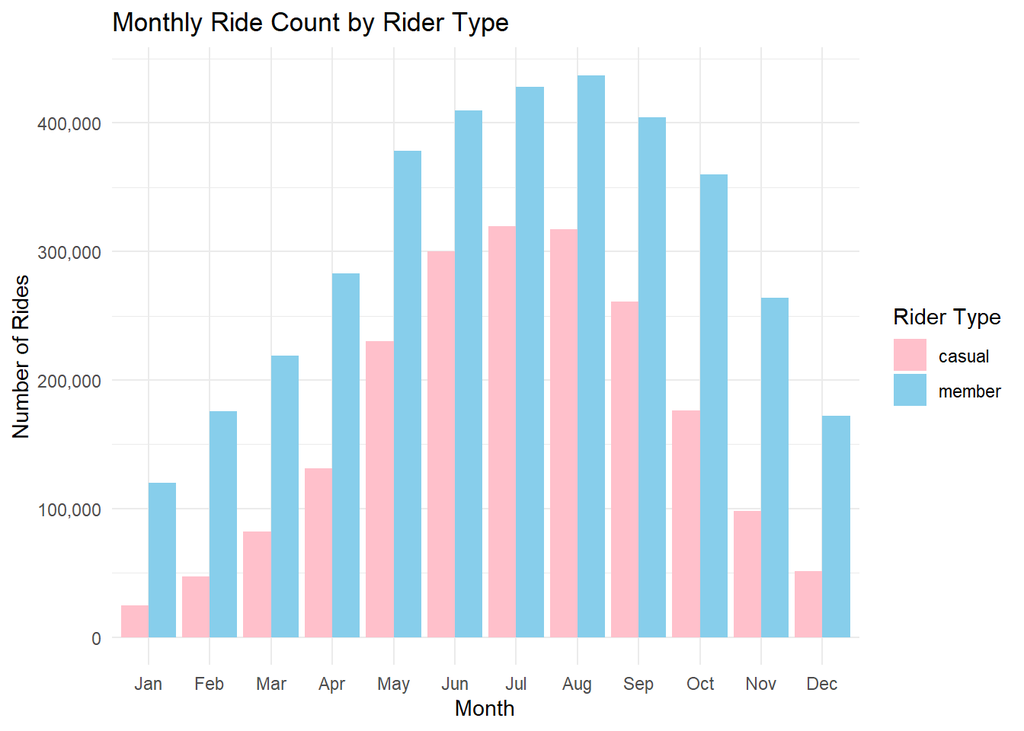

```r
ggplot(rider_info, aes(x = month, fill = member_casual)) +
  geom_bar(position = "dodge") +
  scale_fill_manual(
    values = c("casual" = "pink", "member" = "skyblue")
  ) +
  labs(
    title = "Monthly Ride Count by Rider Type",
    x = "Month",
    y = "Number of Rides",
    fill = "Rider Type"
  ) +
  scale_y_continuous(labels = scales::comma) +
  theme_minimal()
```

### 18. Seasonal Ride Count by Rider Type

This chart shows how rider activity varies by season.

We can observe: - Casual riders peak in the summer, likely due to weather and tourism. - Member riders show more consistent usage across all seasons. - Winter drop-off is especially sharp for casual users.

I have suggested eco-protector campaign.(indicated in the PPT)

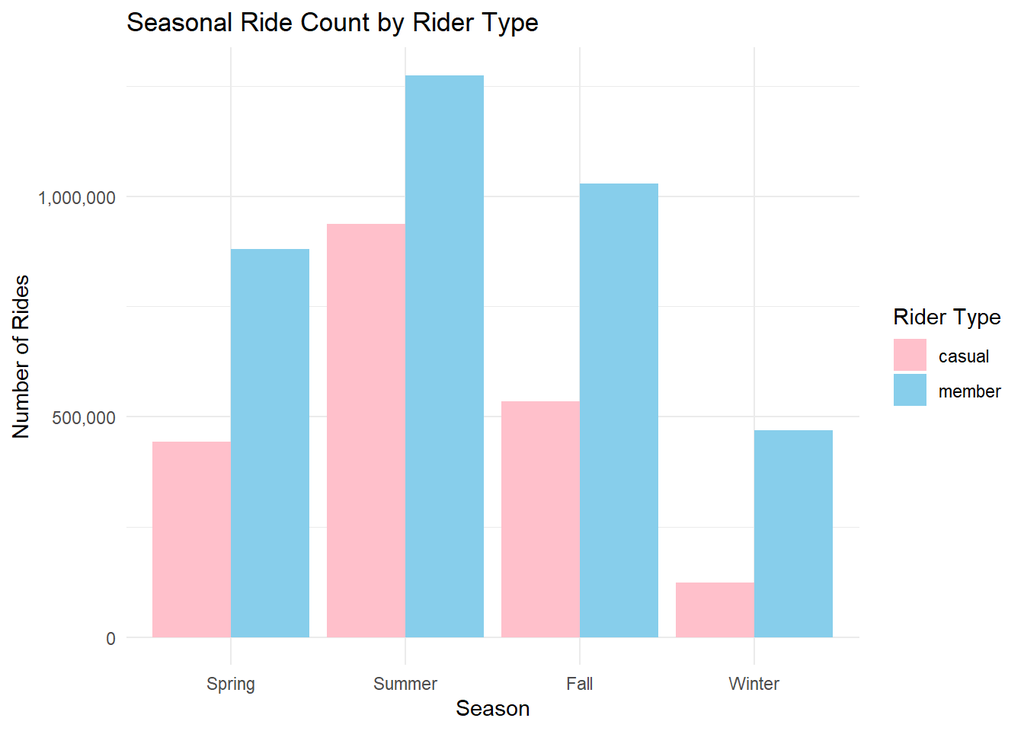

```r
ggplot(rider_info, aes(x = season, fill = member_casual)) +
  geom_bar(position = "dodge") +
  labs(
    title = "Seasonal Ride Count by Rider Type",
    x = "Season",
    y = "Number of Rides",
    fill = "Rider Type"
  ) +
  scale_fill_manual(values = c("casual" = "pink", "member" = "skyblue")) +
  scale_y_continuous(labels = scales::comma) +
  theme_minimal()
```

### 19. Weekly Ride Count by Rider Type

This chart shows how rides taken each day of the week by rider type.

As indicated in the slide, casual riders peak during weekends,  
while members tend to ride more consistently across weekdays, likely due to commuting habits.

I have suggested 2+1 promotion.(indicated in the PPT)

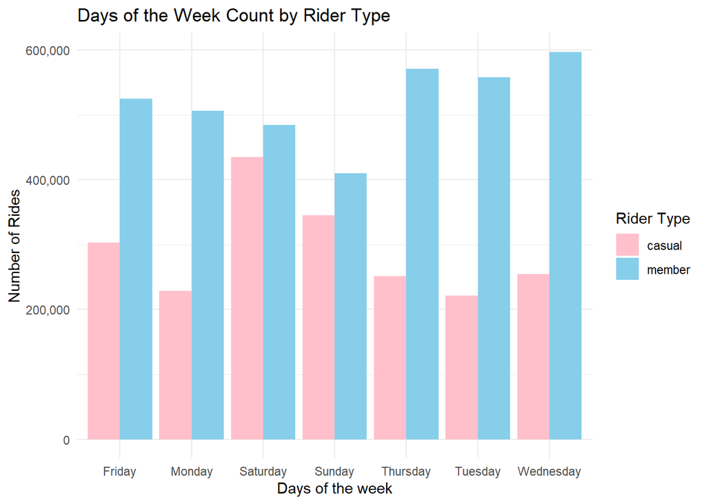

```r
ggplot(rider_info, aes(x = day_of_week, fill = member_casual)) +
  geom_bar(position = "dodge") +
  labs(
    title = "Days of the Week Count by Rider Type",
    x = "Days of the week",
    y = "Number of Rides",
    fill = "Rider Type"
  ) +
  scale_fill_manual(values = c("casual" = "pink", "member" = "skyblue")) +
  scale_y_continuous(labels = scales::comma) +
  theme_minimal()
```

```r
rider_info$day_of_week <- factor(rider_info$day_of_week,
  levels = c("Monday", "Tuesday", "Wednesday", "Thursday", "Friday", "Saturday", "Sunday"),
  ordered = TRUE
)
```

### 20. Classic VS Electric Bike

```r
table(rider_info$rideable_type)
```

```
##
##  classic_bike electric_bike
##       2810237       2880206
```

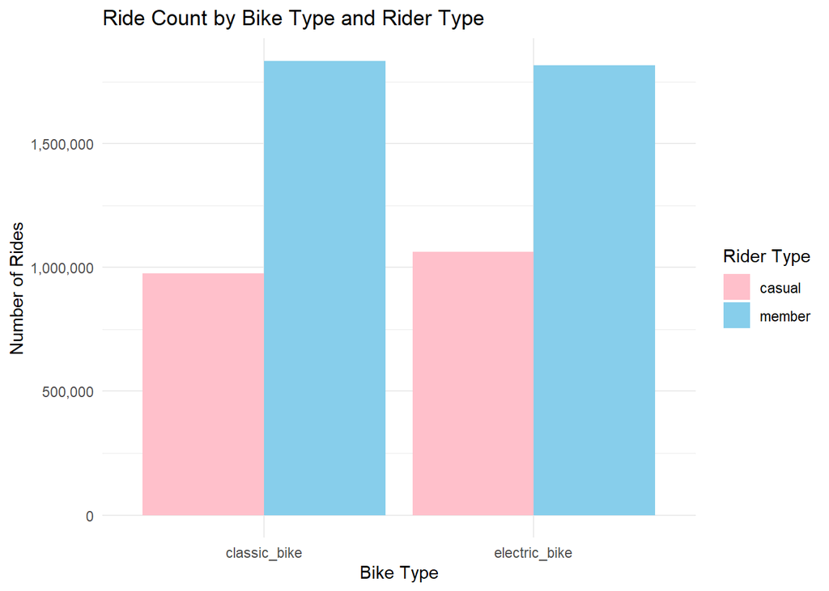

```r
bike_rider_summary <- rider_info %>%
  group_by(rideable_type, member_casual) %>%
  summarise(
    ride_count = n(),
    .groups = "drop"
  )

ggplot(bike_rider_summary, aes(x = rideable_type, y = ride_count, fill = member_casual)) +
  geom_bar(stat = "identity", position = "dodge") +
  labs(
    title = "Ride Count by Bike Type and Rider Type",
    x = "Bike Type",
    y = "Number of Rides",
    fill = "Rider Type"
  ) +
  scale_y_continuous(labels = scales::comma) +
  scale_fill_manual(values = c("casual" = "pink", "member" = "skyblue")) +
  theme_minimal()
```

### 21. Bike Type Preference of Each Rider Type

Although the absolute ride counts appear significantly different in the previous chart,  
the percentage breakdown reveals that both rider types have a fairly balanced usage between classic and electric bikes.

This highlights the importance of choosing the right visual format when interpreting data.

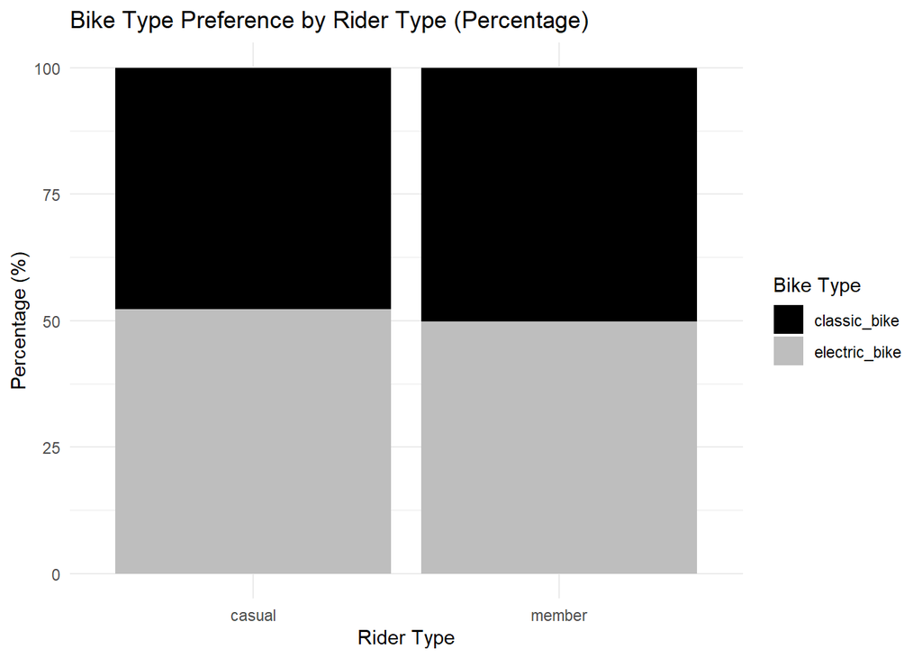

```r
bike_percent <- rider_info %>%
  group_by(member_casual, rideable_type) %>%
  summarise(count = n(), .groups = "drop") %>%
  group_by(member_casual) %>%
  mutate(percent = round(count / sum(count) * 100, 1))


ggplot(bike_percent, aes(x = member_casual, y = percent, fill = rideable_type)) +
  geom_bar(stat = "identity") +
  labs(
    title = "Bike Type Preference by Rider Type (Percentage)",
    x = "Rider Type",
    y = "Percentage (%)",
    fill = "Bike Type"
  ) +
  scale_fill_manual(values = c("classic_bike" = "black", "electric_bike" = "gray")) +
  theme_minimal()
```

Although the absolute ride counts appear significantly different in the previous chart,  
the percentage breakdown reveals that both rider types have a fairly balanced usage between classic and electric bikes.

This highlights the importance of choosing the right visual format when interpreting data.

### 22. Average Ride Length by Bike Type and Rider Type

This chart explores how the duration of rides varies based on both rider type and bike type.

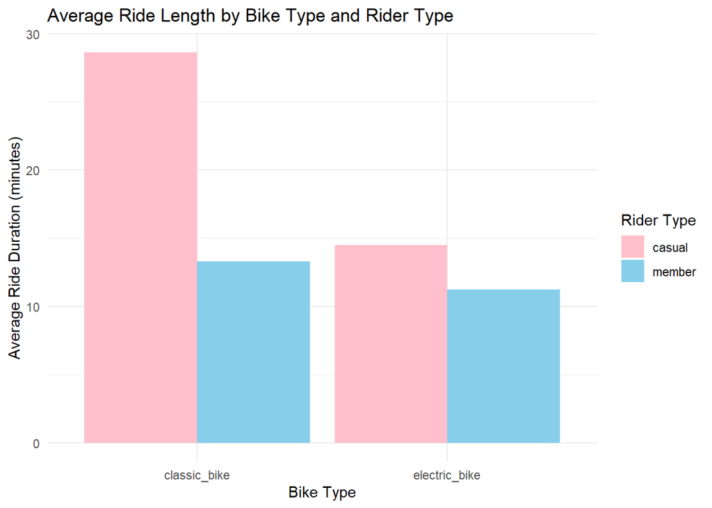

```r
bike_ride_length <- rider_info %>%
  group_by(rideable_type, member_casual) %>%
  summarise(
    avg_ride_length = round(mean(ride_length), 2),
    .groups = "drop"
  )

ggplot(bike_ride_length, aes(x = rideable_type, y = avg_ride_length, fill = member_casual)) +
  geom_bar(stat = "identity", position = "dodge") +
  labs(
    title = "Average Ride Length by Bike Type and Rider Type",
    x = "Bike Type",
    y = "Average Ride Duration (minutes)",
    fill = "Rider Type"
  ) +
  scale_fill_manual(values = c("casual" = "pink", "member" = "skyblue")) +
  theme_minimal()
```

You can find the corresponding presentation slides in this GitHub repository for further reference.